# Final Project GitHub Version

JPBH

12/15/2019

To download the data used here: 1) Go to https://www2.census.gov/programs-surveys/acs/data/pums/2017/5-Year/ 2) Download the data “csv_pma.zip” 3) Unzip the file and set the proper file directory in the code below.

## Overview and Motivation

Head Start is a federal preschool program that serves nearly three quarters of a million children from low-income families every year [1] across the US and US territories [2]. With its foundations in President Lyndon Johnson’s War on Poverty, Head Start is designed to address key issues that disproportionately impact the health and wellbeing of children in low-income families [3,4], such as low school readiness [5,6] and poor nutrition [7,8]. Enrolled children receive instruction with a research-based curriculum, meals and snacks meeting federal nutrition guidelines, as well as medical, dental, and mental health care [9]. Parents of enrolled children can capitalize on such Head Start services as parenting and health education [10]. Head Start also provides opportunities for parents to expand their social networks and take on leadership roles (e.g., parent committees [9]), which may result in further benefits to parents and their children [11]. Evaluations to date have demonstrated positive impacts of these Head Start services on children’s school readiness [12,13] and health [14,15], as well as their parents’ educational advancement [11] and parenting practices [16]. Despite these benefits, the population-level impact of Head Start may be limited by the fact that less than 35% of eligible children are enrolled [17].

For my dissertation work, I am conducting three studies stemming from an obesity prevention trial in Head Start preschools in the greater Boston area. It is unclear if my findings will generalize to the broader population of children in poverty because the children who enroll in Head Start may be systematically different from the eligible children who do not enroll. More importantly, there may be particular subpopulations of eligible children who do not enroll in Head Start and therefore do not enjoy the benefits of the program. For example, if children living in certain neighborhoods are less likely to enroll in Head Start, it may inform Head Start recruitment efforts or even the opening of a new Head Start center to ensure all eligible children have an equal opportunity to enroll in Head Start.

While no existing data provide estimates on the proportion of the poulation enrolled in Head Start specifically, the American Community Survey provides a representative sample of the population and includes data on preschool enrollment.

The purpose of this study is to : 1) describe the population of children who are age- and income-eligible for Head Start living in the greater Boston area 2) identify child and parent characteristics associated with enrollment in preschool among this population

## Initial Questions

1. What are the demographic characteristics of the population of children who are age- and income-eligible for Head Start living in the greater Boston area?
2. What child and parent characteristics are associated with enrollment in preschool among this population?

The answer to question 1 is central to my dissertation work. I will compare the characteristics of this sample to the characteristics of the children enrolled in Head Start in the Greater Boston area (from data not publicly available). Although I do not know which children in the ACS sample are also in my Head Start-enrolled sample, any large differences between the two samples can likely be attributed to eligible children who do not enroll in Head Start.

The answer to question 2 is a natural next step from question 1. However, given the very small sample, there likely is low power to detect associations between population characteristics and preschool enrollment.

## Data

American Community Survey (ACS) Public Use Microdata Sample (PUMS) 2013 - 2017

The ACS provides representative statistics on the population residing in the US each year. Unlike the census, which is a full count of all people in the US every ten years, the ACS collects data from about 2.5% of households each year.

To work with individual-level data in the ACS, it is necessary to use the PUMS, which is a random sample of about 1% of the data from each survey year. To get stable estimates for smaller geographic units, called Public Use Microdata Areas (PUMAs), it is necessary to look at five years of data. Thus, I have selected the most recent five-year data set. For more information on the ACS and PUMS, see:

https://www.census.gov/content/dam/Census/library/publications/2009/acs/ACSPUMS.pdf

To download the data used here: 1) Go to https://www2.census.gov/programs-surveys/acs/data/pums/2017/5-Year/ 2) Download the data “csv_pma.zip” 3) Unzip the file and set the proper file directory in the code below.

## Exploratory Analysis

I divided the exploratory analysis into three chapters: 1) load data and restrict to analytic sample 2) univariate analysis on all variables of interest 3) create table 1

The general approach is to first restrict the data to my analytic sample, then understand the distributions of the variables of interest for this study, and last test for unadjusted associations between those variables and my outcome of interest, enrollment in preschool. I will split each into a separate chunk of R code.

To produce statistics that are representative of the population, it is necessary to use sample weights because this population is not a simple random sample of the population in the greater Boston area. It is also necessary to use specialized methods to obtain valid standard errors.

```r
#load needed packages
library(dplyr)
library(tidyverse)
```

```r
library(ggplot2)
library(survey)
library(srvyr)
library(sf)
library(table1)
library(xtable)
library(stargazer)
library(gridExtra)
#######################################################
#chapter 1 - load data and restrict to analytic sample#
#######################################################
MA_PUMS <- read.csv("C:/Users/jakep/OneDrive/Documents/BST_260_datascience/final project working on code/csv_pma/psam_p25.csv")

#Note: the above line of code must be replaced with the appropriate file directory if run on any computer other than the JPBH's computer.

#To download the data used here:
#1) Go to https://www2.census.gov/programs-surveys/acs/data/pums/2017/5-Year/
#2) Download the data "csv_pma.zip"
#3) Unzip the file and set the proper file directory.


sum(is.na(MA_PUMS$AGEP)) #0
```

```
## [1] 0
```

```r
  #can restrict by age for the whole sample
  prek_age <- MA_PUMS %>% filter(AGEP <= 5 & AGEP >= 2) #depending on when in the year the survey was done, kids can be 2 - 5 years old and enrolled in preschool
    table(prek_age$AGEP)
```

```
##
##    2    3    4    5
## 3070 3241 3218 3382
```

```r
sum(is.na(prek_age$PUMA)) #0
```

```
## [1] 0
```

```r
  #can restrict to study area for the whole sample
  Bos_Cam_Som_prek <- prek_age %>% filter(PUMA == 3301 | PUMA == 3302 | PUMA == 3303 | PUMA == 3304 | PUMA == 3305 | PUMA == 506 | PUMA == 507)

sum(is.na(Bos_Cam_Som_prek$SCH)) #371
```

```
## [1] 371
```

```r
  #need to drop these 371 - missing the outcome of this study
  Bos_Cam_Som_prek <- Bos_Cam_Som_prek %>% filter(!(is.na(SCH)))

sum(is.na(Bos_Cam_Som_prek$SCHG)) #289
```

```
## [1] 289
```

```r
  xtabs(~ Bos_Cam_Som_prek$SCH + Bos_Cam_Som_prek$SCHG, addNA = TRUE)
```

```
##                     Bos_Cam_Som_prek$SCHG
## Bos_Cam_Som_prek$SCH   1   2   3   4 <NA>
##                    1   0   0   0   0  289
##                    2 211 230   5   4    0
##                    3 241  56   1   0    0
```

```r
  #289 missing here. Note that everyone with SCH == 1 is missing on SCHG. Need to look at missingness in SCHG among kids with SCH != 1
  Bos_Cam_Som_prek %>% filter(SCH != 1) %>% summarize(sum(is.na(SCHG)))
```

```
##   sum(is.na(SCHG))
## 1                0
```

```r
    #among kids in school (i.e., SCH != 1), all have a grade. (This is also apparent in the crosstab)



#some of the 5 year olds currently in the sample will be in kindergarten. need to remove them.
#Some of the 2 year olds currently in the sample may not be old enough for prechool.

  #age by school - are there 2 and/or 5 year olds who are in pre-k?
  xtabs(~ Bos_Cam_Som_prek$AGEP + Bos_Cam_Som_prek$SCH, addNA = TRUE)
```

```
##                      Bos_Cam_Som_prek$SCH
## Bos_Cam_Som_prek$AGEP   1   2   3
##                     3 161  82 109
##                     4  84 148 115
##                     5  44 220  74
```

```r
  #all 2 year olds got dropped when I dropped missing SCH
  #note that 44 5 year olds are not in school, 294 are
      xtabs(~ prek_age$AGEP + prek_age$SCH, addNA = TRUE)
```

```
##              prek_age$SCH
## prek_age$AGEP    1    2    3 <NA>
##             2    0    0    0 3070
##             3 1642  638  961    0
##             4  879 1198 1141    0
##             5  374 2215  793    0
```

```r
      #confirmed - all 2 y/o kids missing on the SCH variable, so they all got dropped


  #age by school grade - any 5 year olds in pre-k?
  xtabs(~ Bos_Cam_Som_prek$AGEP + Bos_Cam_Som_prek$SCHG, addNA = TRUE)
```

```
##                      Bos_Cam_Som_prek$SCHG
## Bos_Cam_Som_prek$AGEP   1   2   3   4 <NA>
##                     3 178  13   0   0  161
##                     4 198  65   0   0   84
##                     5  76 208   6   4   44
```

```r
  #yes - some 5 year olds in nursery/pre-k (SCHG == 1).
  #note also some 3- and 4- year olds in kindergarten (SCHG == 2), some 5-year olds in 1st or 2nd grade (SCHG == 3, 4)
    #a total of 296 kids from this sampe in kindergarten, 1st, or 2nd

#I will restrict to only the 3-5 y/o kids in pre-k or not in school
right_grades <- Bos_Cam_Som_prek %>% filter(SCHG == 1 | SCH == 1) #741 kids left
xtabs(~ right_grades$AGEP + right_grades$SCHG, addNA = TRUE)
```

```
##                  right_grades$SCHG
## right_grades$AGEP   1 <NA>
##                 3 178  161
##                 4 198   84
##                 5  76   44
```

```r
sum(is.na(right_grades$POVPIP)) #12
```

```
## [1] 12
```

```r
  #only 12 missing POVPIP among the kids of prek age not in school or in prek. I'm going to restrict on this too b/c it is so central to my focus on Head Start
  right_grades <- right_grades %>% filter(!(is.na(POVPIP)))



final_analytic_sample <- right_grades %>% filter(POVPIP <= 130)

#This is now my final sample: 3 - 5 y/o kids, living in the study area, not in school or in pre-k, and income-eligible for Head Start
```

```r
##############################################################
#chapter 2 - univariate analysis on all variables of interest#
##############################################################

#outcome: in pre-k
table(final_analytic_sample$SCHG, useNA = "always")
```

```
##
##    1 <NA>
##   88  113
```

```r
  #88 in prek, 113 not in school
  #need to code a new 0/1 variable for being in prek

#ind var: age
table(final_analytic_sample$AGEP, useNA = "always")
```

```
##
##    3    4    5 <NA>
##   81   81   39    0
```

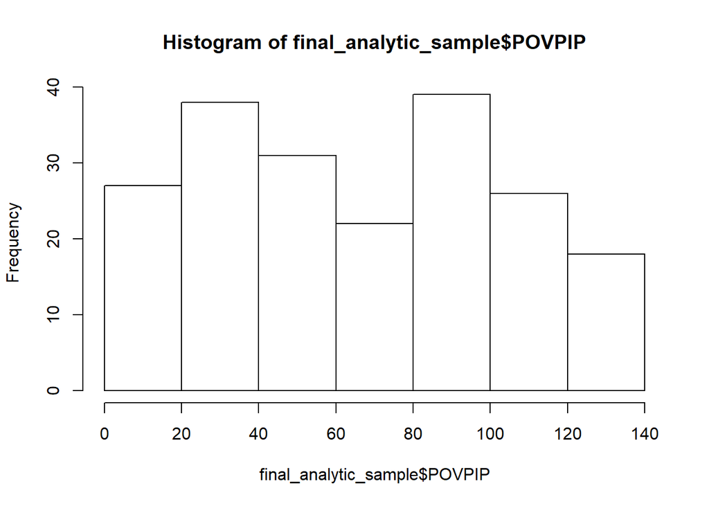

```r
#ind var and determinant of Head Start eligibility: income
hist(final_analytic_sample$POVPIP)
```

```r
#ind var and sampling design factor: PUMA
table(final_analytic_sample$PUMA, useNA = "always")
```

```
##
##  506  507 3301 3302 3303 3304 3305 <NA>
##    7   23   10   33   39   67   22    0
```

```r
#ind var: sex
table(final_analytic_sample$SEX, useNA = "always")
```

```
##
##    1    2 <NA>
##   91  110    0
```

```r
  #(male is 1, female is 2)

#ind var: nativity
table(final_analytic_sample$NATIVITY, useNA = "always")
```

```
##
##    1    2 <NA>
##  188   13    0
```

```r
  #188 native, 13 foreign born

#ind var: race
table(final_analytic_sample$RAC1P, useNA = "always")
```

```
##
##    1    2    5    6    8    9 <NA>
##   67   76    2   14   22   20    0
```

```r
  #1 = white
  #2 = black/aa
  #3 = american indian
  #4 = alaska native
  #5 = american indian and alaska native tribes specified
  #6 = asian
  #7 = native hawaiian or pacific islander
  #8 = other race
  #9 = two or more races
    #need to collapse american indian into other


#ind var: ethnicity
table(final_analytic_sample$HISP, useNA = "always")
```

```
##
##    1    2    3    5    7    8   11   12   24 <NA>
##  114    5   29   21    2    3   17    1    9    0
```

```r
  #no missing, 114 not hispanic (1) and the rest are Hispanic. need to recode and combine with race


#ind var: citizenship status
table(final_analytic_sample$CIT, useNA = "always")
```

```
##
##    1    2    4    5 <NA>
##  184    4    5    8    0
```

```r
  #1 = born in US
  #2 = born in PI, USVI, or norther marianas
  #3 = born abroad to US parents
  #4 = US citizen by naturalization
  #5 = not US citizen
    #I want to just collapse to US citizen or not

#ind var: mobility status
table(final_analytic_sample$MIG, useNA = "always")
```

```
##
##    1    2    3 <NA>
##  164    3   34    0
```

```r
  #1 = lived in this household 1 year ago
  #2 = lived outside US/PR 1 year ago
  #3 = lived in different household in US/PR 1 year ago

#ind var: employment status of parents
table(final_analytic_sample$ESP, useNA = "always")
```

```
##
##    1    2    3    4    5    6    7    8 <NA>
##   26   29    4    5    7    1   87   38    4
```

```r
  #1 = Living with two parents: both parents in labor force
  #2 = Living with two parents: Father only in labor force
  #3 = Living with two parents: Mother only in labor force
  #4 = Living with two parents: Neither parent in labor force
  #5 = Living with father: Father in the labor force
  #6 = Living with father: Father not in labor force
  #7 = Living with mother: Mother in the labor force
  #8 = Living with mother: Mother not in labor force

#ind var: nativity of parent
table(final_analytic_sample$NOP, useNA = "always")
```

```
##
##    1    2    3    4    5    6    7    8 <NA>
##   16    6    4   38    3    5   69   56    4
```

```r
  #1 = Living with two parents: both parents native
  #2 = Living with two parents: Father only foreign born
  #3 = Living with two parents: Mother only foreign born
  #4 = Living with two parents: Both foreign born
  #5 = Living with father: Father native
  #6 = Living with father: Father foreign born
  #7 = Living with mother: Mother native
  #8 = Living with mother: Mother foreign born


###########################
#chapter 2.1 - recode vars#
###########################

#outcome variable - 0/1 for in pre-k
final_analytic_sample$in_prek <- NA
final_analytic_sample$in_prek[final_analytic_sample$SCHG == 1] <- 1
final_analytic_sample$in_prek[is.na(final_analytic_sample$SCHG)] <- 0
  xtabs(~ final_analytic_sample$in_prek + final_analytic_sample$SCHG, addNA = TRUE)
```

```
##                              final_analytic_sample$SCHG
## final_analytic_sample$in_prek   1 <NA>
##                             0   0  113
##                             1  88    0
```

```r
#outcome variable character
  final_analytic_sample$in_prek_char <- NA
  final_analytic_sample$in_prek_char[final_analytic_sample$SCHG == 1] <- 'In Pre-K'
  final_analytic_sample$in_prek_char[is.na(final_analytic_sample$SCHG)] <- 'Not in Pre-K'
  xtabs(~ final_analytic_sample$in_prek_char + final_analytic_sample$SCHG, addNA = TRUE)
```

```
##                                   final_analytic_sample$SCHG
## final_analytic_sample$in_prek_char   1 <NA>
##                       In Pre-K      88    0
##                       Not in Pre-K   0  113
```

```r
#recoding sex to female to it is easier to know which is which
final_analytic_sample$female <- NA
final_analytic_sample$female[final_analytic_sample$SEX == 2] <- 1
final_analytic_sample$female[final_analytic_sample$SEX == 1] <- 0
  xtabs(~ final_analytic_sample$SEX + final_analytic_sample$female, addNA = TRUE)
```

```
##                          final_analytic_sample$female
## final_analytic_sample$SEX   0   1
##                         1  91   0
##                         2   0 110
```

```r
#collapsing some of the race categories and combining with hispanic
final_analytic_sample$race_eth <- NA
final_analytic_sample$race_eth[final_analytic_sample$HISP != 1] <- "Hispanic"
final_analytic_sample$race_eth[final_analytic_sample$HISP == 1 & final_analytic_sample$RAC1P == 1] <- "NH White"
final_analytic_sample$race_eth[final_analytic_sample$HISP == 1 & final_analytic_sample$RAC1P == 2] <- "NH Black/AA"
final_analytic_sample$race_eth[final_analytic_sample$HISP == 1 & final_analytic_sample$RAC1P == 6] <- "NH Asian"
final_analytic_sample$race_eth[final_analytic_sample$HISP == 1 & (final_analytic_sample$RAC1P %in% c(3, 4, 5, 7, 8, 9))] <- "NH Other"
  xtabs(~ final_analytic_sample$race_eth + final_analytic_sample$HISP, addNA = TRUE)
```

```
##                               final_analytic_sample$HISP
## final_analytic_sample$race_eth  1  2  3  5  7  8 11 12 24
##                    Hispanic     0  5 29 21  2  3 17  1  9
##                    NH Asian    14  0  0  0  0  0  0  0  0
##                    NH Black/AA 66  0  0  0  0  0  0  0  0
##                    NH Other     8  0  0  0  0  0  0  0  0
##                    NH White    26  0  0  0  0  0  0  0  0
```

```r
  xtabs(~ final_analytic_sample$race_eth + final_analytic_sample$RAC1P, addNA = TRUE)
```

```
##                               final_analytic_sample$RAC1P
## final_analytic_sample$race_eth  1  2  5  6  8  9
##                    Hispanic    41 10  2  0 20 14
##                    NH Asian     0  0  0 14  0  0
##                    NH Black/AA  0 66  0  0  0  0
##                    NH Other     0  0  0  0  2  6
##                    NH White    26  0  0  0  0  0
```

```r
  xtabs(~ final_analytic_sample$HISP + final_analytic_sample$RAC1P, addNA = TRUE)
```

```
##                           final_analytic_sample$RAC1P
## final_analytic_sample$HISP  1  2  5  6  8  9
##                         1  26 66  0 14  2  6
##                         2   1  1  1  0  1  1
##                         3  16  7  1  0  2  3
##                         5   6  1  0  0 11  3
##                         7   1  0  0  0  0  1
##                         8   1  1  0  0  0  1
##                         11 12  0  0  0  1  4
##                         12  0  0  0  0  0  1
##                         24  4  0  0  0  5  0
```

```r
#creating binary var for US citizenship
final_analytic_sample$UScitizen <- NA
final_analytic_sample$UScitizen[final_analytic_sample$CIT %in% c(1, 2, 3, 4)] <- 1
final_analytic_sample$UScitizen[final_analytic_sample$CIT == 5] <- 0
  xtabs(~ final_analytic_sample$CIT + final_analytic_sample$UScitizen, addNA = TRUE)
```

```
##                          final_analytic_sample$UScitizen
## final_analytic_sample$CIT   0   1
##                         1   0 184
##                         2   0   4
##                         4   0   5
##                         5   8   0
```

```r
#create binary variable for having moved in past year
final_analytic_sample$moved_past_yr <- NA
final_analytic_sample$moved_past_yr[final_analytic_sample$MIG %in% c(2, 3)] <- 1
final_analytic_sample$moved_past_yr[final_analytic_sample$MIG == 1] <- 0
  xtabs(~ final_analytic_sample$moved_past_yr + final_analytic_sample$MIG, addNA = TRUE)
```

```
##                                    final_analytic_sample$MIG
## final_analytic_sample$moved_past_yr   1   2   3
##                                   0 164   0   0
##                                   1   0   3  34
```

```r
#create binary variable for parent employment
final_analytic_sample$parent_employed <- NA
final_analytic_sample$parent_employed[final_analytic_sample$ESP %in% c(1, 5, 7)] <- 1
final_analytic_sample$parent_employed[final_analytic_sample$ESP %in% c(2, 3, 4, 6, 8)] <- 0
  xtabs(~ final_analytic_sample$parent_employed + final_analytic_sample$ESP, addNA = TRUE)
```

```
##                                      final_analytic_sample$ESP
## final_analytic_sample$parent_employed  1  2  3  4  5  6  7  8 <NA>
##                                  0     0 29  4  5  0  1  0 38    0
##                                  1    26  0  0  0  7  0 87  0    0
##                                  <NA>  0  0  0  0  0  0  0  0    4
```

```r
#create binary variable for parent nativity
final_analytic_sample$ge1parent_native <- NA
final_analytic_sample$ge1parent_native[final_analytic_sample$NOP %in% c(1, 2, 3, 5, 7)] <- 1
final_analytic_sample$ge1parent_native[final_analytic_sample$NOP %in% c(4, 6, 8)] <- 0
  xtabs(~ final_analytic_sample$ge1parent_native + final_analytic_sample$NOP, addNA = TRUE)
```

```
##                                       final_analytic_sample$NOP
## final_analytic_sample$ge1parent_native  1  2  3  4  5  6  7  8 <NA>
##                                   0     0  0  0 38  0  5  0 56    0
##                                   1    16  6  4  0  3  0 69  0    0
##                                   <NA>  0  0  0  0  0  0  0  0    4
```

```r
#create variable for number of parents in household
xtabs(~ final_analytic_sample$ESP + final_analytic_sample$NOP, addNA = TRUE)
```

```
##                          final_analytic_sample$NOP
## final_analytic_sample$ESP  1  2  3  4  5  6  7  8 <NA>
##                      1     6  2  0 18  0  0  0  0    0
##                      2     8  2  3 16  0  0  0  0    0
##                      3     2  0  0  2  0  0  0  0    0
##                      4     0  2  1  2  0  0  0  0    0
##                      5     0  0  0  0  3  4  0  0    0
##                      6     0  0  0  0  0  1  0  0    0
##                      7     0  0  0  0  0  0 41 46    0
##                      8     0  0  0  0  0  0 28 10    0
##                      <NA>  0  0  0  0  0  0  0  0    4
```